# Code Sample

Wayne Monical

3/3/2021

### Part 1: Data Cleaning and Correcting

Loading and cleaning the data frame. Each row of this data frame contains the information of one stock’s price on one day between 2012 and 2016. Highlights include correcting the date information for weekends, holidays and leap years, as well as correcting negative entries.

```r
library(dplyr)

# data load
stock_rawdata <- read.csv("stock_data.csv", header = TRUE)
```

Displayed here are the number of times that each stock appears in the data frame. The vast majority of stocks appear exactly 1342 times. The stocks that do not appear this number of times are highlighted in red.

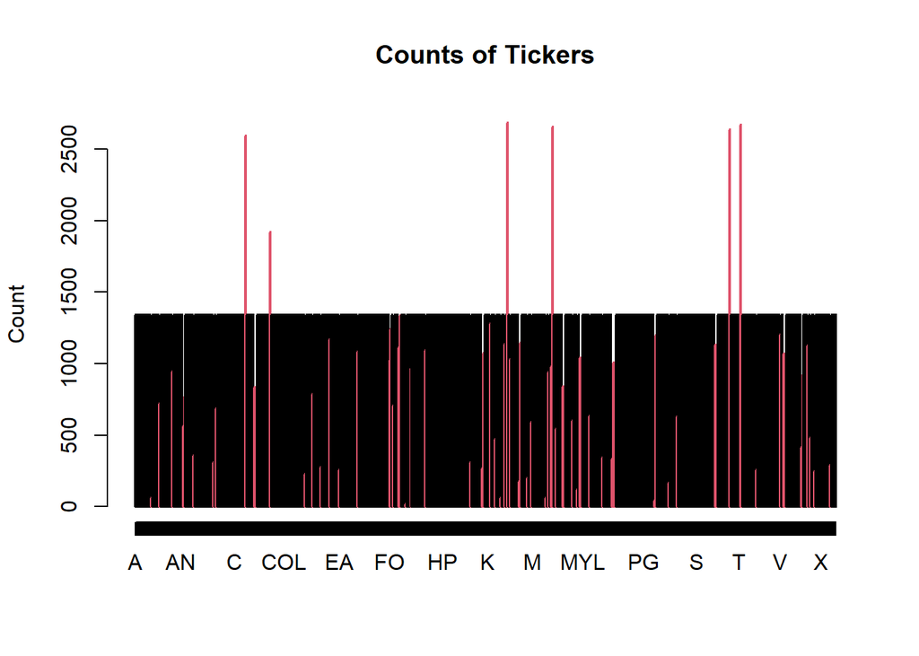

```r
plot(table(stock$TICKER),
     main = "Counts of Tickers",
     ylab = "Count",
     col = factor(!stock_boolean))
```

```r
dateform <- as.Date(as.character(stock$date), format = '%Y%m%d')
```

As is highlighted in red below, you can see that between 2012 and 2014, the value of CMT’s stock went negative several times. Or more likely, the prices on these days were simply not entered correctly. Given that the absolute value of these prices are close to the prices of the dates around them, it is very likely that these prices were simply entered as the negative of their true price.

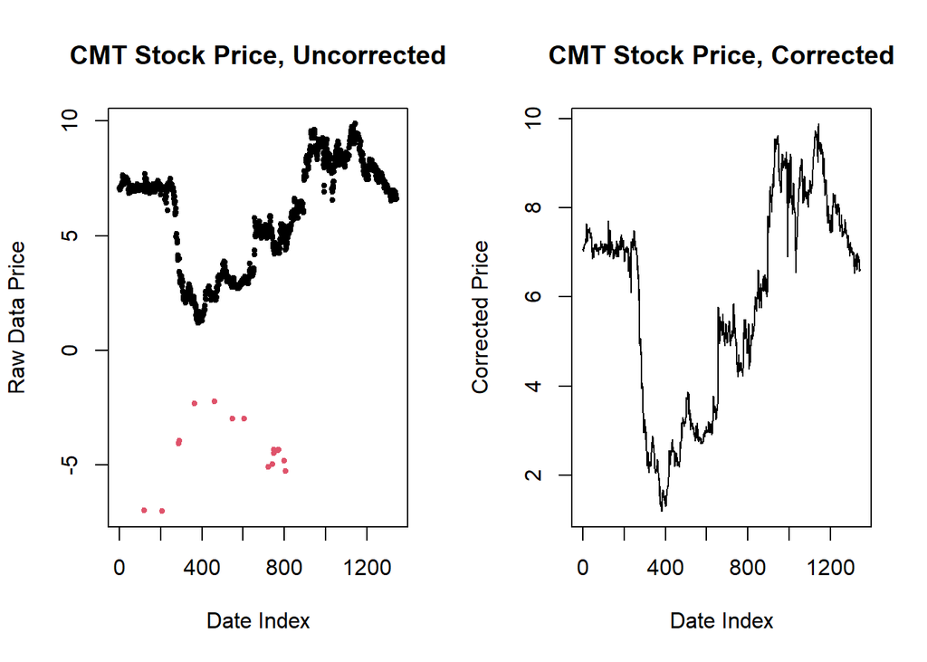

```r
# plotting corrected and uncorrected side by side
par(mfrow = c(1, 2))
plot(cmt$PRC, pch = 20, main = "CMT Stock Price, Uncorrected",
     xlab = "Date Index", ylab = "Raw Data Price",
     col = factor(cmt$PRC < 0), cex = 0.8)
plot(abs(cmt$PRC), type = 'l', main = "CMT Stock Price, Corrected",
     xlab = "Date Index" , ylab = "Corrected Price")
```

### Part 2: kNN Prediction Function

Here, I construct a simple function to predict an unknown variable from a data set using a simple averaging of its K nearest neighbors. It takes the number of nearest numbers, the training set, and the value to predict at which to predict as arguments. When K equal to N, where N is the number of data points in the training set, the function will return a simple average. `knn.predict` relies on the auxiliary function `closest.k`, which indicates which data points are to be used in prediction.

```r
# predicts the response at value, from data
knn.predict <- function(value, response, data, k = 1){
  mat_closest <- closest.k(k = k, vec = data, value = value)

  temp_index <- mat_closest[1:k,1]


  closest_response <- response[temp_index]

  return(sum(closest_response) / k)
}
```

The `knn.apply` function is a simple wrapper for the `knn.predict` function so that it may be called on a sequence of values. This function is helpful when applying `knn.predict` to multiple training sets in parallel.

```r
# apply wrapper
knn.apply <- function(sequence, response, data, k){
  answer <- sapply(X = sequence, FUN = function(x){knn.predict(value = x, response = response, data = data , k = k)})
  return(answer)
}
```

### Part 3: Graphics and Analysis

Here, I take an initial look at a small subset of stocks and their prices. For a simple analysis, I will split each stock’s prices into a training and test set, then apply the K nearest neighbors prediction function to each training set in order to predict the values of the test set. I will plot my predictions, and finally aggregate a table displaying each model’s mean squared-error on its training and test set.

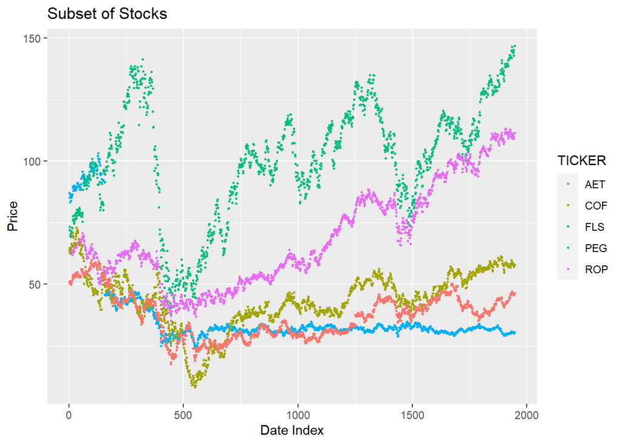

```r
library(ggplot2)

# initial plot
ggplot(data = stock_subset, aes(x = date_num,  y = PRC)) + geom_point(aes(col = TICKER), size = 0.5) +
  ggtitle("Subset of Stocks") +
  labs(x = "Date Index", y = "Price")
```

The line of code below predicts the values of the FLS stock with the K nearest neighbors method. here, K is equal to 10

```r
# applying kNN to FLS on date index
predict_FLS <- knn.apply(sequence = date_sequence, response = train_FLS$PRC, data = train_FLS$date_num, k = k_star)
```

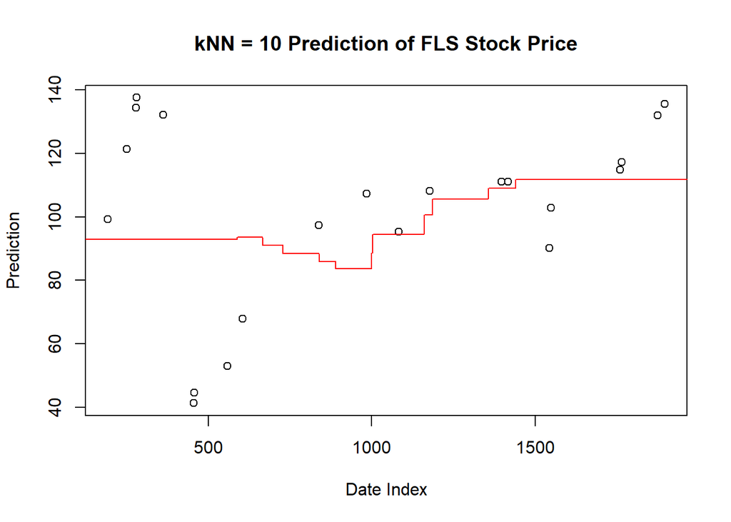

Here, I construct the exact same plot in ggplot2

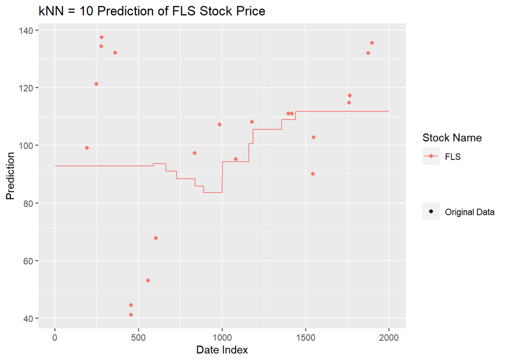

```r
ggplot(data = train_FLS, ) +
         geom_point(data = subset(train_FLS, data_type == "Original Data"),
                    aes(x = date_num, y = PRC, color = TICKER, shape = data_type)) +
         geom_line(data = subset(train_FLS, data_type == "Prediction"),
                   aes(x = date_num, y = PRC, color = TICKER)) +
         ggtitle(label = "kNN = 10 Prediction of FLS Stock Price") +
         labs(x = "Date Index", y = "Prediction", col = "Stock Name", shape = "")
```

With a for-loop, we can apply the exact same process to all stocks in the subset. Here, the extra steps of filtering and binding to construct the ggplot data frames are not omitted. Finally, all ggplot data frames are row-binded so that they may be plotted together.

```r
# predicing the other stock prices from kNN
for(g in ticker_subset){

  df_g <- filter(stock_train, TICKER == g)
  predict_g <- knn.apply(sequence = date_sequence, response = df_g$PRC,
                         data = df_g$date_num, k = k_star)

  df_predict_g <- data.frame(TICKER = g, PRC = predict_g,
                             date_num = date_sequence, data_type = "Prediction")


  stock_train <- rbind(stock_train, df_predict_g)
}
```

On the graph below, the points represent the training set data. The lines represent the K nearest neighbor method’s predictions. Training sets are predictions are matched by stock, indicated with color, as specified by the legend. These graphic elements are added with additional functions `geom_point`, `geom_line`, and `ggtitle`. One subtle but imperative point in this graphic’s programming is the liberal use of the `subset` function. This function differentiates between the observed and predicted data, i.e. which data must be represented by points and which must be represented by lines. Both are simply encoded as rows in data frame.

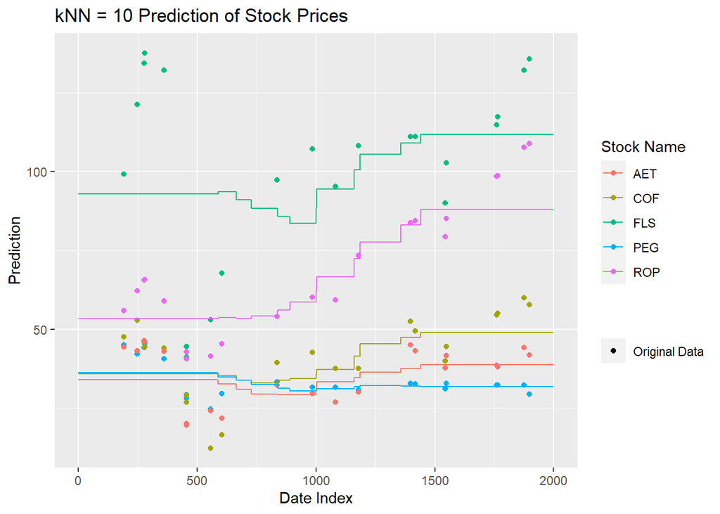

```r
  #### Initialize Plot

         ggplot(data = stock_train) +


  #### Data Elements

         geom_point(data = subset(stock_train, data_type == "Original Data"),
                    aes(x = date_num, y = PRC, color = TICKER, shape = data_type)) +

         geom_line(data = subset(stock_train, data_type == "Prediction"),
                   aes(x = date_num, y = PRC, color = TICKER)) +



  #### Label Elements

         ggtitle(label = paste0("kNN = ", k_star," Prediction of Stock Prices")) +

         labs(x = "Date Index", y = "Prediction", col = "Stock Name", shape = "")
```

Here I use simple aggregation method to compare the mean squared-error of the models on the training and test set. Comparison of these errors are essential to validating models and avoiding over-fitting.

```r
empirical_error[1,] <- aggregate(stock_merge_train[,"Error"], list(stock_merge_train$TICKER), mean)$x
empirical_error[2,] <- aggregate(stock_merge_test[,"Error"], list(stock_merge_test$TICKER), mean)$x


empirical_error
```

```
##               COF      FLS      AET      ROP      PEG
## test     6.768714 8.761476 21.60686 3.739238 8.116810
## training 6.036263 8.016815 17.47076 6.902248 8.005949
```